# JO2024

Mathilde Buffard

2025-01-24

Rapport Stage Janvier 2025 à l’Institut de Mathématiques de Toulouse :

## Importation

```r
library(readxl)
```

```r
library(ggplot2)
library(dplyr)
library(localScore)
JO2024Finale <- read_excel("JO2024Finale.xlsx")
BasketJO_1_ <- read_excel("BasketJO (1).xlsx")
Book_2 <- read_excel("Book 2.xlsx")
```

## Including Plots

Durant ce stage, j’avais pour mission d’analyser le moment momentum durant un match, avec pour objectifs de découvrir le language de programmation Rstudio. J’ai ainsi choisi la finale des Jeux Olympiques 2024 en Basket Masculin qui opposait la France au USA.

J’ai donc réalisé une analyse complète de la durée de la possession de chaque équipe afin d’observer les moments décisifs de ce match.

Tout d’abord, voici un graphique qui compare le type d’issue à chaque fin de possession des deux équipes.

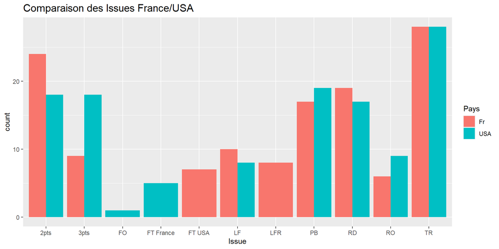

```r
#Graphique Issue
BarIssue <- ggplot(data = BasketJO_1_) +
  geom_bar(aes(x=Issue), position = "dodge") +
  labs(title="Comparaison des Issues France/USA")

BarIssue + aes(fill=Pays) + theme(plot.title=element_text(size=15))
```

```r
#Graphique Evolution du Score
BasketJO_1_$Possessions <- as.numeric(substring(BasketJO_1_$Possesions, first=2))
GraphiqueEvol <- ggplot(BasketJO_1_, aes(x=Possessions, y=Evolution_Score, col=Pays)) + labs(
  title = "Évolution du score des équipes",
  x = "Durée",
  y="Score"
) +
  geom_line(linewidth=1.5) +
  geom_vline(xintercept=31, linewitdh=18) +
  geom_vline(xintercept = 66, linewitdh=18) +
  geom_vline(xintercept = 100, linewitdh=18) +
  annotate("text", x=15, y=25, label="QT1", cex=10) +
  annotate("text", x=60, y=25, label="QT2", cex=10) +
  annotate("text", x=90, y=25, label="QT3", cex=10) +
  annotate("text", x=120, y=25, label="QT4", cex=10)+
  theme(plot.title=element_text(size=45), legend.title = element_text(size = 35), legend.text= element_text(size = 33))
```

Nous continuons avec 10 graphiques qui nous permettent de comparer la moyenne de possession par QT et par équipe.

```r
#QT1
#MoyennePQT1
MoyennePQT1France <- mean(JO2024Finale$`Durée (s)`[1:30])
MoyennePQT1USA <- mean(JO2024Finale$`Durée (s)`[66:96])

#Même Feuille
split.screen(2:1)
```

```
## [1] 1 2
```

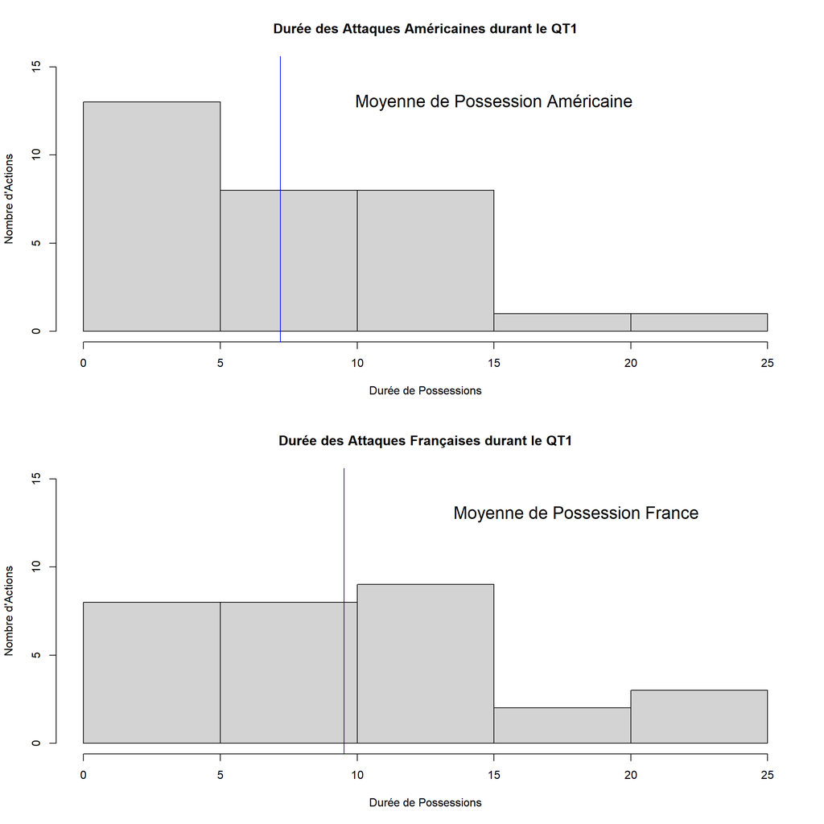

```r
screen(2)
hist(JO2024Finale$`Durée (s)`[1:30],
     main="Durée des Attaques Françaises durant le QT1",
     xlab="Durée de Possessions", ylab="Nombre d'Actions",
     xlim=c(0, 25), ylim=c(0,15))
abline(v=MoyennePQT1France, col="blue")
text(18, 13, "Moyenne de Possession France", cex=1.5, col="black")
screen(1)
hist(JO2024Finale$`Durée (s)`[66:96],
     main="Durée des Attaques Américaines durant le QT1",
     xlab="Durée de Possessions", ylab="Nombre d'Actions",
     xlim=c(0, 25), ylim=c(0, 15)
     )
abline(v=MoyennePQT1USA, col="blue")
text(15, 13, "Moyenne de Possession Américaine", cex=1.5, col="black")
```

```r
#QT2
#MoyennePQT2
MoyennePQT2France <- mean(JO2024Finale$`Durée (s)`[31:65])
MoyennePQT2USA <- mean(JO2024Finale$`Durée (s)`[97:126])

#Même Feuille
split.screen(2:1)
```

```
## [1] 3 4
```

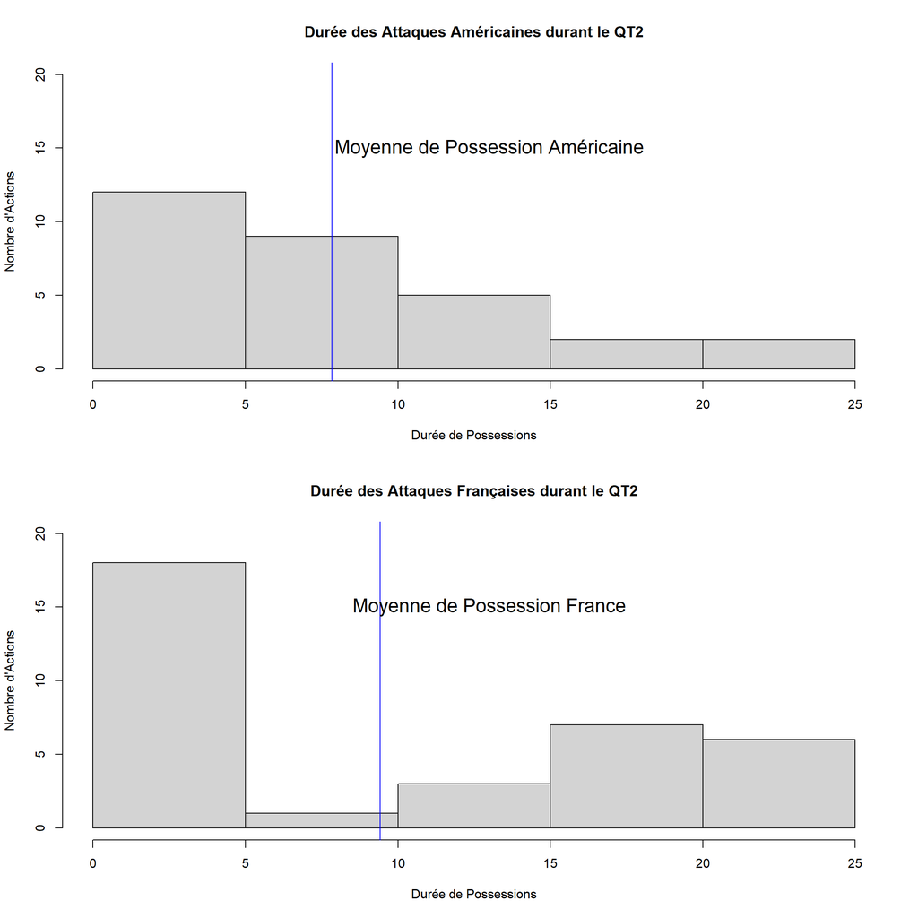

```r
screen(1);hist(JO2024Finale$`Durée (s)`[97:126],
               main="Durée des Attaques Américaines durant le QT2",
               xlab="Durée de Possessions", ylab="Nombre d'Actions",
               xlim=c(0, 25), ylim=c(0, 20))
abline(v=MoyennePQT2USA, col="blue")
text(13, 15, "Moyenne de Possession Américaine", cex=1.5, col="black")
screen(2);hist(JO2024Finale$`Durée (s)`[31:65],
     main="Durée des Attaques Françaises durant le QT2",
     xlab="Durée de Possessions", ylab="Nombre d'Actions",
     xlim=c(0, 25), ylim=c(0, 20))
abline(v=MoyennePQT2France, col="blue")
text(13, 15, "Moyenne de Possession France", cex=1.5, col="black")
```

```r
#QT3
#Moyenne QT3
MoyennePQT3France <- mean(JO2024Finale$`Durée (s)`[127:158])
MoyennePQT3USA <- mean(JO2024Finale$`Durée (s)`[159:194])

#Même Feuille
split.screen(2:1)
```

```
## [1] 5 6
```

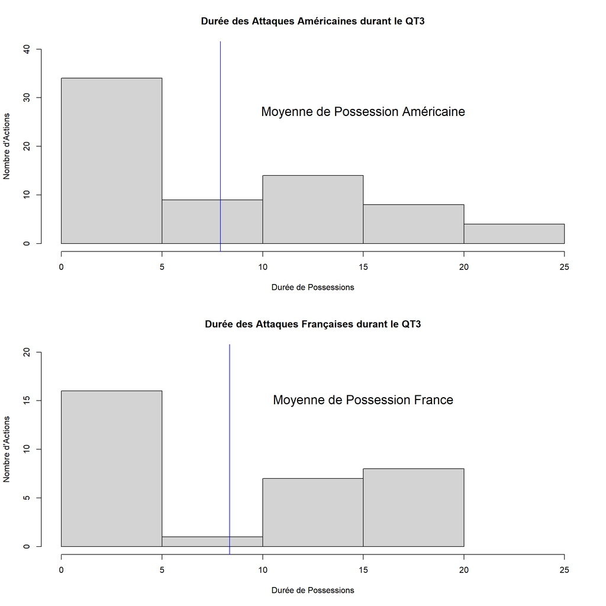

```r
screen(2)
hist(JO2024Finale$`Durée (s)`[127:158],
     main="Durée des Attaques Françaises durant le QT3",
     xlab="Durée de Possessions", ylab="Nombre d'Actions",
     xlim=c(0, 25), ylim=c(0, 20))
abline(v=MoyennePQT3France, col="blue")
text(15, 15, "Moyenne de Possession France", cex=1.5, col="black")
screen(1)
hist(JO2024Finale$`Durée (s)`[159:227],
               main="Durée des Attaques Américaines durant le QT3",
               xlab="Durée de Possessions", ylab="Nombre d'Actions",
               xlim=c(0, 25), ylim=c(0, 40))
abline(v=MoyennePQT3USA, col="blue")
text(15, 27, "Moyenne de Possession Américaine", cex=1.5, col="black")
```

```r
#QT4
#Moyenne QT4
MoyennePQT4France <- mean(JO2024Finale$`Durée (s)`[195:227])
MoyennePQT4USA <- mean(JO2024Finale$`Durée (s)`[228:256])

#Même Feuille
split.screen(2:1)
```

```
## [1] 7 8
```

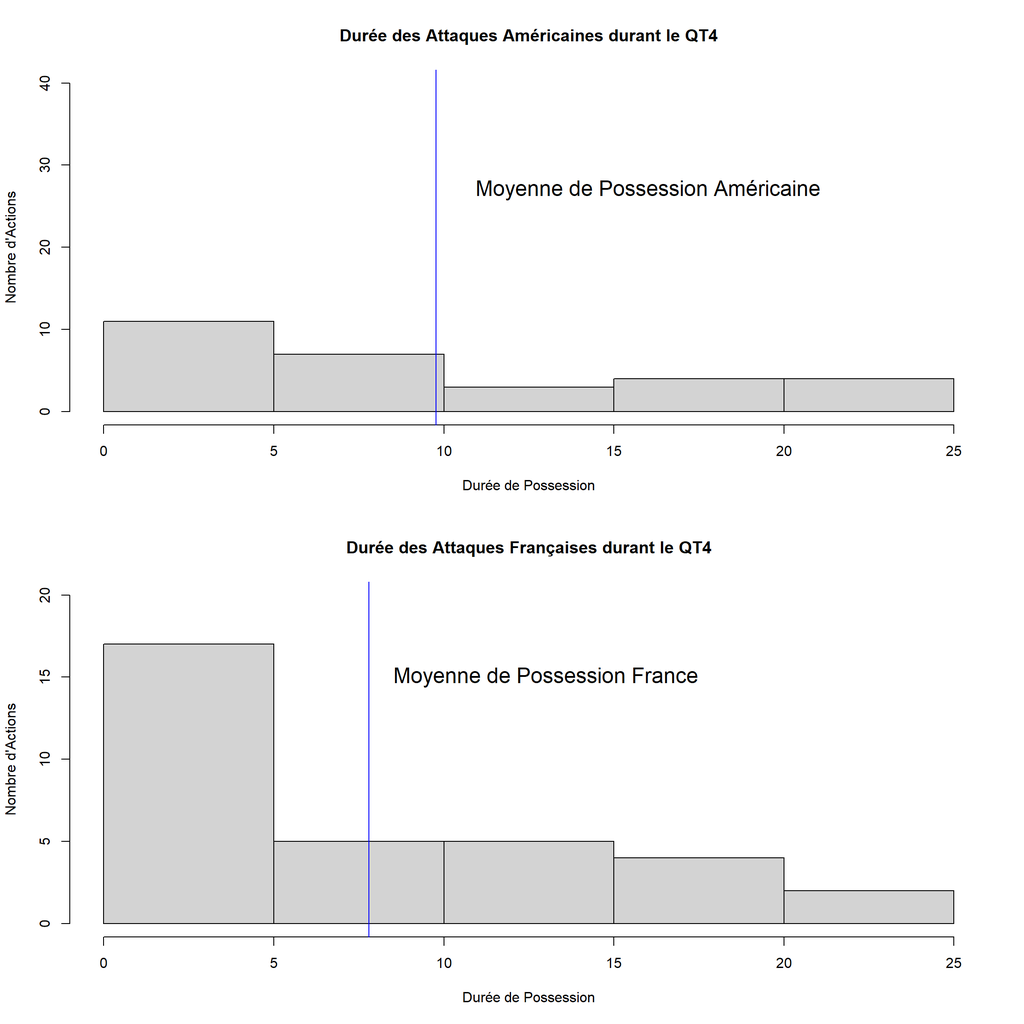

```r
screen(2)
hist(JO2024Finale$`Durée (s)`[195:227],
     main="Durée des Attaques Françaises durant le QT4",
     xlab="Durée de Possession", ylab="Nombre d'Actions",
     xlim=c(0, 25), ylim=c(0, 20))
abline(v=MoyennePQT4France, col="blue")
text(13, 15, "Moyenne de Possession France", cex=1.5, col="black")
screen(1)
hist(JO2024Finale$`Durée (s)`[228:256],
     main="Durée des Attaques Américaines durant le QT4",
     xlab="Durée de Possession", ylab="Nombre d'Actions",
     xlim=c(0, 25), ylim=c(0, 40))
abline(v=MoyennePQT4USA, col="blue")
text(16, 27, "Moyenne de Possession Américaine", cex=1.5, col="black")
```

```r
#QTMoyenneduMatch

MoyenneFrance <-mean(BasketJO_1_$Duree[1:128])
MoyenneUSA <- mean(BasketJO_1_$Duree[129:251])


split.screen(2:1)
```

```
## [1]  9 10
```

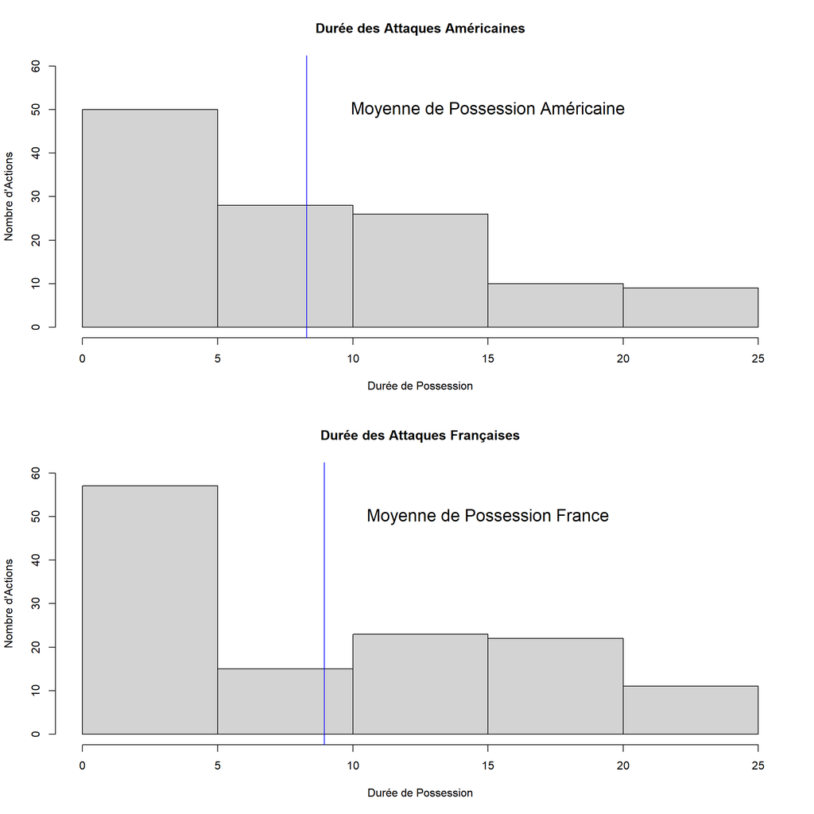

```r
screen(2)
hist(BasketJO_1_$Duree[1:128],
     main="Durée des Attaques Françaises",
     xlab="Durée de Possession", ylab="Nombre d'Actions",
     xlim=c(0, 25), ylim=c(0, 60))
abline(v=MoyenneFrance, col="blue")
text(15, 50, "Moyenne de Possession France", cex=1.5, col="black")
screen(1)
hist(BasketJO_1_$Duree[129:251],
     main="Durée des Attaques Américaines",
     xlab="Durée de Possession", ylab="Nombre d'Actions",
     xlim=c(0, 25), ylim=c(0, 60))
abline(v=MoyenneUSA, col="blue")
text(15, 50, "Moyenne de Possession Américaine", cex=1.5, col="black")
```

Ainsi, nous concluons que la moyenne de possession américaine est plus faible que celle de la France. Les attaques américains sont principalement axés sur deux points:

- de faible durée
- répétition dans ces attaques

Ensuite, j’ai réalisé un graphique qui étudie la densité de possession de chaque équipe. Nous avons un tableau qui nous aide à comparer ces densités par QT et par équipe. Le suivant nous apporte une aide supplémentaire, avec une densité moyenne de chaque équipe.

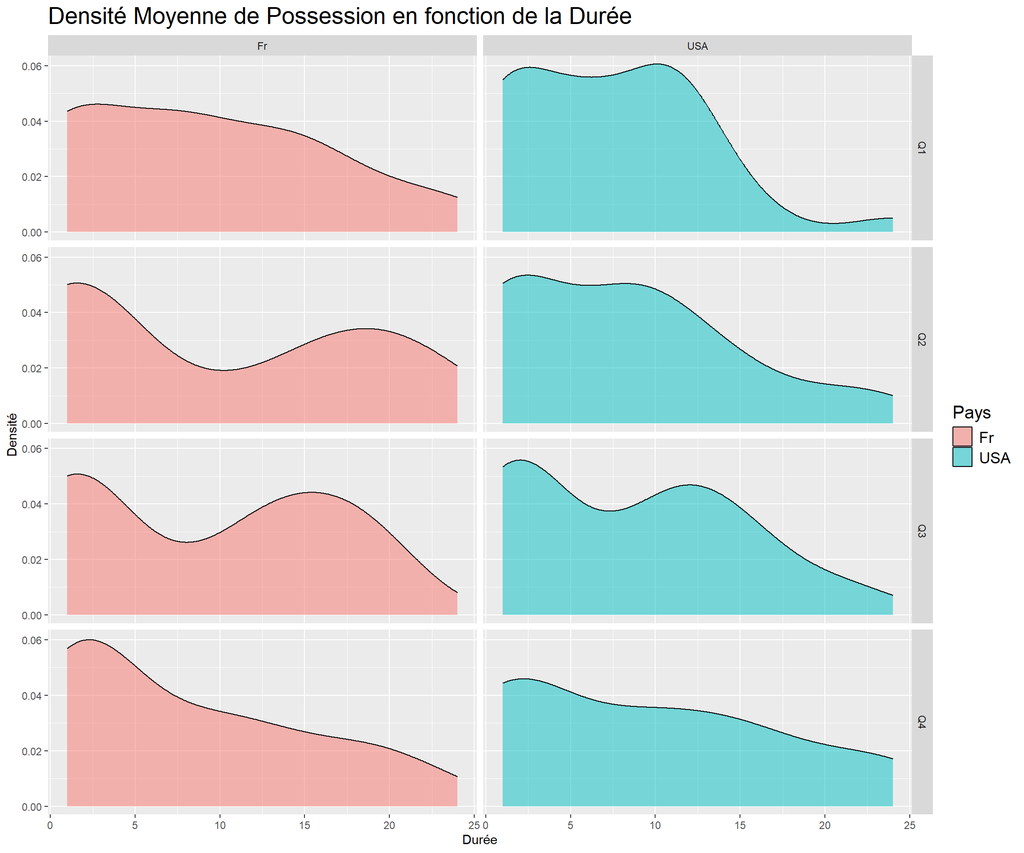

```r
#Graphique Possession (QT1, QT2, QT3, QT4, Moyenne du match) en Grille
ggplot(data = BasketJO_1_, aes(x= `Duree`, fill=Pays)) + labs(
  title = "Densité Moyenne de Possession en fonction de la Durée",
  x = "Durée",
  y = "Densité"
) +
  geom_density(alpha=0.5)+
  facet_grid(QT~Pays)+
  theme(plot.title=element_text(size=20), legend.title = element_text(size=15), legend.text = element_text(size=13))
```

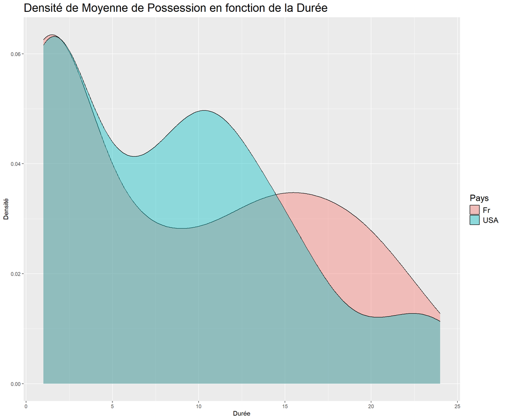

```r
ggplot(data = BasketJO_1_, aes(x= `Duree`, fill=Pays)) +
  labs(
    title = "Densité de Moyenne de Possession en fonction de la Durée",
    x = "Durée",
    y = "Densité") +
  geom_density(alpha=0.4) +
  facet_grid() +
  theme(plot.title=element_text(size=20), legend.title = element_text(size=15), legend.text = element_text(size=13))
```

Nous faisons donc le même constat, la possession américaine est plus courte et répétitive comparée à la France.

Nous remarquons grâce aux précédents graphiques, que le QT2 est un moment décisif pour le match. C’est à partir de ce QT que la France sera menée et ne reviendra plus au score.

Voici deux graphiques qui ont zoomés sur le QT2. Le premier graphique nous montre l’évolution du score du QT, et le deuxième graphique a pour but de représenter la durée de possesion des deux équipes.

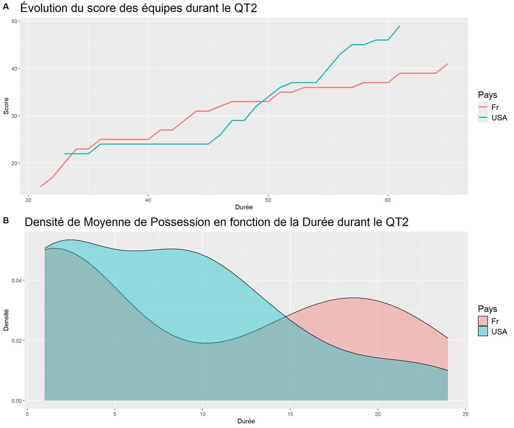

```r
#Graphique Evolution Score QT2, sélectionnez un caractère
library(cowplot)
BasketJO_1_$Possessions <- as.numeric(substring(BasketJO_1_$Possesions, first=2))
fig1 <- ggplot(BasketJO_1_[BasketJO_1_$QT == "Q2",], aes(x= Possessions, y=Evolution_Score, col=Pays)) +
  labs(
  title = "Évolution du score des équipes durant le QT2",
  x = "Durée",
  y="Score",
) +
  geom_line(linewidth=1) +
  theme(plot.title=element_text(size=20), legend.title = element_text(size=15), legend.text = element_text(size=13))


fig2 <- ggplot(data = BasketJO_1_[BasketJO_1_$QT == "Q2",], aes(x= `Duree`, fill=Pays)) +
  labs(
  title = "Densité de Moyenne de Possession en fonction de la Durée durant le QT2",
  x = "Durée",
  y = "Densité") +
  geom_density(alpha=0.4) +
  facet_grid() +
  theme(plot.title=element_text(size=20), legend.title = element_text(size=15), legend.text = element_text(size=13))
plot_grid(fig1, fig2, labels=c("A", "B"), ncol=1, nrow = 2)
```

Grâce à des graphiques, nous constatons que les actions des USA sont principalement courtes et efficaces puisqu’ils sont devant au score. Contrairement à la France qui met plus de temps à attaquer.

Deuxièment, les résultats trouvés avec la fonction localScore pour essayer de déterminer le moment “Momentum”.

https://theanalyst.com/eu/2021/11/what-is-match-momentum, un article qui explique la signification de ce nouveau terme.

Les deux premiers graphiques correspondent à ceux de la France et les deux derniers à l’USA.

```r
#localScore
filtered_data <- Book_2%>%filter(Issue %in% c("3pts", "2pts", "TR", "LF")) %>%
  mutate(Evolution_Score = case_when( Issue == "3pts" & Pays== "USA" ~ -3,
                                      Issue == "3pts" & Pays== "Fr" ~ 3,
                                      Issue == "2pts" & Pays == "USA" ~ -2,
                                      Issue == "2pts" & Pays == "Fr" ~
2,
                                      Issue == "LF" & Pays == "USA" ~ -1,
                                      Issue == "LF" & Pays == "Fr"~ 1,
                                      Issue == "TR" ~ 0))

#localScoreFrançais
print(filtered_data)
```

```
## # A tibble: 143 × 13
##    Action Pays  QT    Duree Issue Evolution_Score Possessions ...8  ...9  ...10
##    <chr>  <chr> <chr> <dbl> <chr>           <dbl> <chr>       <lgl> <lgl> <lgl>
##  1 A1     USA   Q1       12 TR                  0 P1          NA    NA    NA
##  2 A3     Fr    Q1       14 TR                  0 P3          NA    NA    NA
##  3 A4     USA   Q1        5 2pts               -2 P4          NA    NA    NA
##  4 A5     Fr    Q1        8 3pts                3 P3          NA    NA    NA
##  5 A6     USA   Q1        6 3pts               -3 P6          NA    NA    NA
##  6 A7     Fr    Q1        7 2pts                2 P7          NA    NA    NA
##  7 A9     Fr    Q1       15 2pts                2 P9          NA    NA    NA
##  8 A11    Fr    Q1       20 TR                  0 P11         NA    NA    NA
##  9 A13    USA   Q1        6 TR                  0 P13         NA    NA    NA
## 10 A15    Fr    Q1        7 TR                  0 P15         NA    NA    NA
## # ℹ 133 more rows
## # ℹ 3 more variables: ...11 <lgl>, ...12 <lgl>, ...13 <chr>
```

```r
localScoreC(filtered_data$Evolution_Score)
```

```
## $localScore
## value begin   end
##    11    91   130
##
## $suboptimalSegmentScores
##    value begin end
## 1      3     4   4
## 2      4     6   7
## 3      4    15  17
## 4      2    28  28
## 5      2    32  32
## 6      2    38  38
## 7      8    41  46
## 8      3    66  67
## 9      3    72  73
## 10     2    76  76
## 11     2    81  81
## 12     2    85  85
## 13     2    88  89
## 14    11    91 130
##
## $RecordTime
##  [1]  0  3 14 30 35 37 69 70 84 90
```

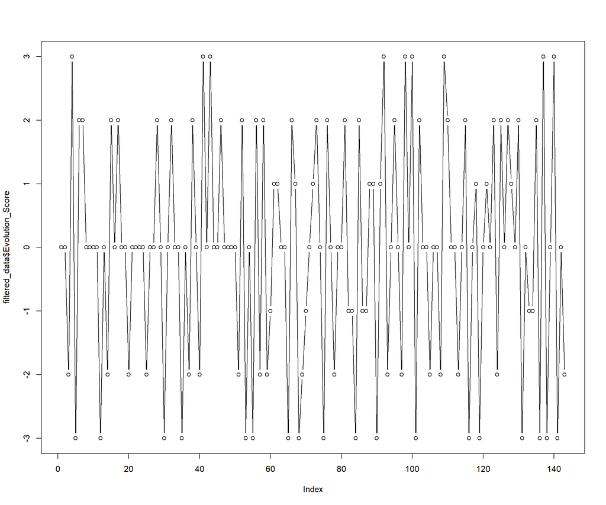

```r
plot(filtered_data$Evolution_Score, type="b")
```

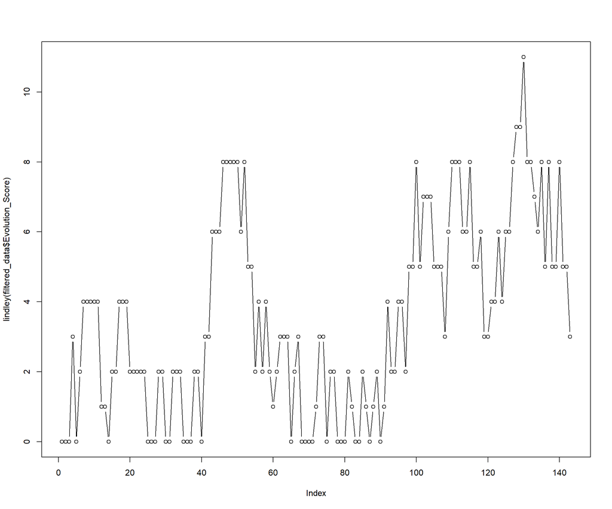

```r
plot(lindley(filtered_data$Evolution_Score), type="b")
```

```r
#localScoreUSA
localScoreC(-filtered_data$Evolution_Score)
```

```
## $localScore
## value begin   end
##    16    12    90
##
## $suboptimalSegmentScores
##   value begin end
## 1     2     3   3
## 2     3     5   5
## 3    16    12  90
##
## $RecordTime
## [1] 0 4 7
```

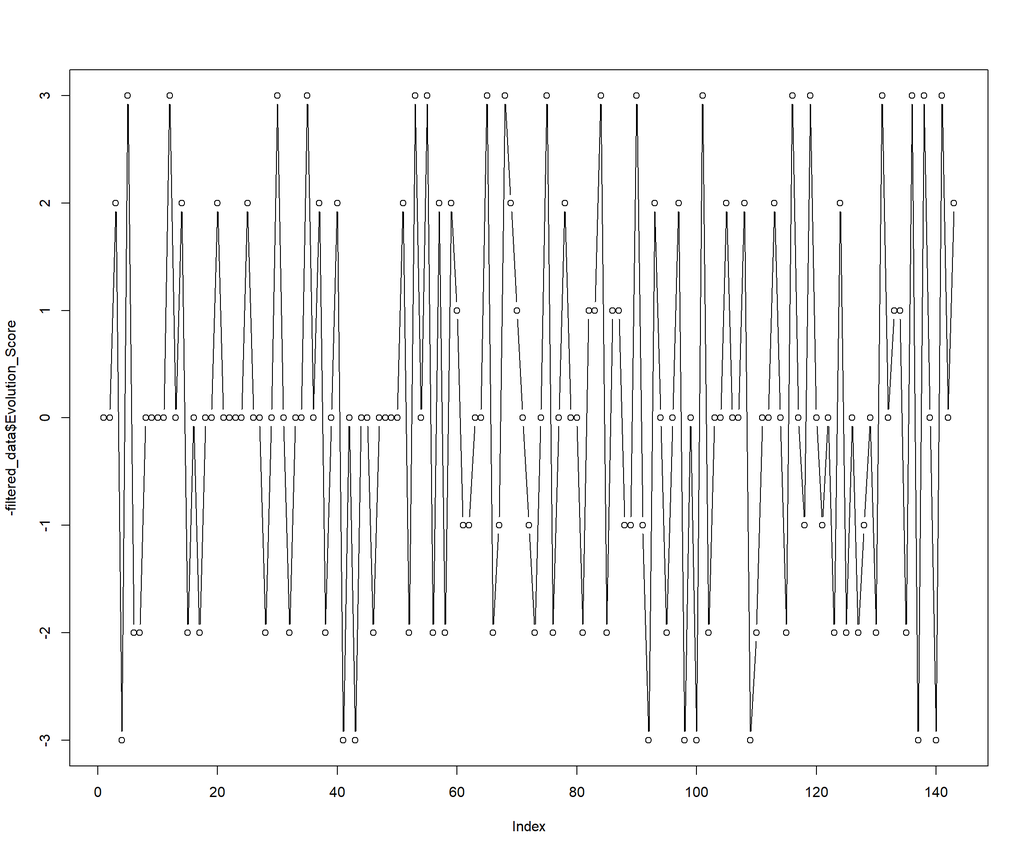

```r
plot(-filtered_data$Evolution_Score, type="b")
```

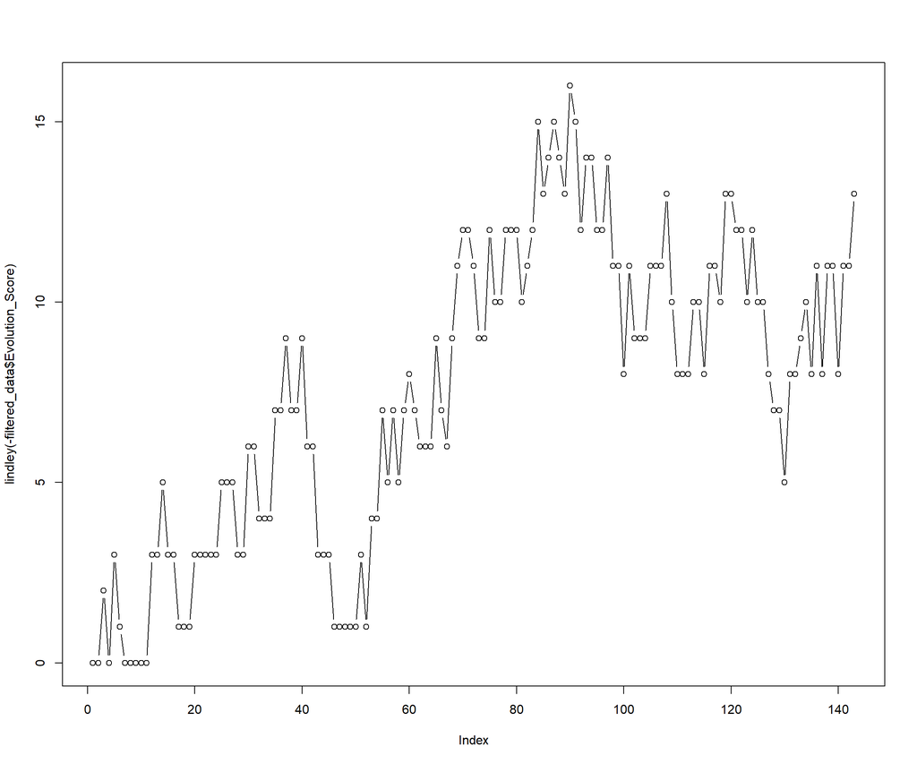

```r
plot(lindley(-filtered_data$Evolution_Score), type="b")
```